# CCS 消融实验数据审计

Bensz Conan

2026-09-17

本报告是数据审计阶段，同时审计 32 特征主输入、biology anchor 的完整表达矩阵派生缓存、组织标签恢复和 reference-query 原始构成。它不运行表示学习，也不根据样本量、效应大小或显著性阈值筛选数据；确认性表示实验的资格条件与结果由 02-ablation03-representation.Rmd 单独报告。

之所以把数据审计放在所有模型分析之前，是因为模型就像按花名册分组做游戏：如果同一个班被写成两个名字，或者不同班被误写成一个名字，后面的分数再精确也回答错了问题。本阶段先确认“有多少人、分别来自哪里、哪些人用于参照、哪些人用于提问”，让客户先看懂实验地基是否可靠，再进入 d1 与 Direct-GSClassifier 的比较。

## 数据概览

表达 RDS 共含 39112 个样本和 193 个 cohort。历史结构只有 10 个顶层 tissue，其中 `Undefined` 汇集了 45 个已知 cohort、8626 个样本。经核验映射恢复后得到 32 个 tissue，未解析样本数为 **0**；样本与 cohort 总数保持不变。

这里先检查组织标签恢复，是为了确认标签修正没有增加、删除或重复任何样本。下面的表逐个展示历史 `Undefined` cohort 的来源和核验后去向，客户可直接审查每次恢复是否有依据。

```r
# Purpose: Show every historical Undefined cohort and its audited destination.
# Input: Complete tissue-resolution audit from 01-ablation-test-data.R.
# Parameters: Ten rows per page; no mapping record is filtered.
# Output: Interactive mapping table with sample counts and analysis roles.
render_dt(
  data_profile$resolution_audit[, c(
    "cohort", "source_tissue", "resolved_tissue", "sample_count",
    "feature_count", "analysis_set"
  )],
  pageLength = 10
)
```

|  | cohort | source_tissue | resolved_tissue | sample_count | feature_count | analysis_set |
| --- | --- | --- | --- | --- | --- | --- |
| 1 | MSK-BLCA-2013 | Undefined | BLCA | 58 | 32 | reference_atlas |
| 2 | Cornell-NatCom-2019 | Undefined | BLCA | 32 | 32 | reference_atlas |
| 3 | TCGATARGET-BLCA | Undefined | BLCA | 407 | 32 | external_query |
| 4 | TCGATARGET-CESC | Undefined | CESC | 306 | 32 | external_query |
| 5 | MET500-PanCan-2018_CHOL | Undefined | CHOL | 45 | 32 | reference_atlas |
| 6 | TCGATARGET-CHOL | Undefined | CHOL | 36 | 32 | external_query |
| 7 | CPTAC-GBM-2021 | Undefined | GBM | 99 | 32 | external_query |
| 8 | TCGATARGET-GBM | Undefined | GBM | 166 | 32 | external_query |
| 9 | MET500-PanCan-2018_HNSC | Undefined | HNSC | 45 | 32 | reference_atlas |
| 10 | TCGATARGET-HNSC | Undefined | HNSC | 520 | 32 | external_query |

[output cut: 35 more lines]

#### 结果解读

观察：下面的明细表逐条保留历史 `Undefined` cohort 的来源、恢复组织和样本数。The table displays each mapping and its sample count, so any difference in totals is visible. 结论：恢复过程只改变组织标签，不应改变样本或表达值；任何无法对应的 cohort 都应在这里暴露。

恢复规模最大的三个 tissue 是 LUAD = 996; LGG = 982; MISC = 640 个样本。冻结 CCS bank 仍保留历史 `bank_tissue/bank_cohort_key` 作为 module provenance，真实 `tissue/cohort_key` 则用于数据分层。**双键并存避免了把历史存储标签误当成未知组织，同时保留 43 个 external filtered cohort 的模型追溯能力。**

## 关键函数、参数与源代码位置

| 分析过程/产物 | 关键函数/对象 | 关键参数 | 本次设置理由 | 源代码位置 |
| --- | --- | --- | --- | --- |
| tissue 标签恢复 | `.atd_resolve_tissue_groups()` | 源标签 `Undefined` | 只使用已核验映射，不按 cohort 名称猜测 tissue | 01a-ablation03-prepare-data_functions.R:66 |
| 双 cohort key | `.atd_resolve_cohort_keys()` | `bank_cohort_key` / `cohort_key` | 同时满足冻结模型追溯与真实 tissue 分层 | 01a-ablation03-prepare-data_functions.R:99 |
| 全量数据画像 | `.atd_build_data_profile()` | 不应用业务阈值 | 保留全部 cohort 与样本供审计，展示层不改变数据 | 01a-ablation03-prepare-data_functions.R:115 |
| 审计产物 | `saveRDS()` | E:/RCloud/RFactory/ccs/test/ablation-03/tmp/01-data/data-profile.rds | 让 Rmd 不重复加载完整表达矩阵与冻结模型 | 01a-ablation03-prepare-data.R |
| biology anchor 摘要 | `.atd_biology_profile()` | E:/RCloud/RFactory/ccs/test/ablation-03/tmp/01-biology/expression-anchor-cache.rds | 复用完整表达矩阵派生缓存，集中审计 anchor 基因覆盖，不在 Rmd 重算大矩阵 | 01a-ablation03-prepare-data_functions.R:221 |

## 指标取值与通俗解读

本表集中说明数据审计指标的范围、趋势和通俗含义。后续正文只报告本次结果，不再重复定义这些尺子。

| 指标 | 取值范围 | 意义（包括趋势变化） | 通俗解读 |
| --- | --- | --- | --- |
| sample 数 | 从零开始的整数，没有固定上限 | 增加表示样本规模扩大；不自动代表证据更独立或质量更好 | 像班里的孩子人数：人多说明队伍大，不代表来自更多学校 |
| cohort 数 | 从零开始的整数，没有固定上限 | 增加通常表示独立队列覆盖扩大；相同样本数下，更多 cohort 可减少单一大队列主导 | 像参加比赛的班级数：多个班比一个超大班更能检验结果是否普遍 |
| tissue 数 | 从零开始的整数，没有固定上限 | 增加表示组织背景覆盖更广；不同 tissue 的样本量仍需分别审查 | 像覆盖了更多年级，但每个年级有多少孩子仍要单独看 |
| 未解析样本数 | 零至全部样本数 | 零最理想；上升表示更多样本无法进入可靠的组织分层 | 像花名册上找不到班级的孩子，越少越好 |
| reference/query 占比 | 零至一（含端点），也可写成零至百分之百 | 表示参照样本和待检验样本各占多少；变化反映角色构成，不存在单纯越高越好 | reference 像例题，query 像新题；两边都要有，比例本身不是考试分数 |
| source 占比 | 零至一（含端点），同一 tissue 内各来源之和为一 | 某来源占比升高表示该 tissue 更依赖单一数据来源，来源混杂风险增大 | 像照片越来越多来自同一台相机，看到的色调可能是相机造成的 |
| 对数坐标位置 | 仅适用于正数，没有固定上限或满分 | 相同距离代表倍数变化；位置升高只表示数量级增大，不表示效果更强 | 像把很长和很短的尺子压缩到同一张纸上，让小数值也看得见 |

## 样本与 reference-query 构成

这一步要回答“模型从谁身上学习，又拿谁来接受检验”。先看各组织中 reference 与 query 的数量，是为了避免某个组织因参照样本特别多而看起来天然更好，也避免把样本量优势误当成方法优势。

```r
# ==== Data Figure 1: Tissue composition (user-adjustable parameters) ====
fig_data1 <- list(
  # Tall canvas for all tissue labels; increase when labels become denser.
  width_in = 7.4,
  height_in = 8.8,
  # Base font in pt; values below 8 are avoided for print readability.
  base_size = 9,
  # Bar width controls separation between tissue rows.
  bar_width = 0.76,
  # External legend avoids covering the data panel.
  legend_position = "bottom"
)

p_data1 <- ggplot2::ggplot(
  tissue_profile_plot,
  ggplot2::aes(
    x = .data$sample_count,
    y = .data$tissue,
    fill = .data$analysis_set
  )
) +
  ggplot2::geom_col(width = fig_data1$bar_width) +
  ggplot2::scale_fill_manual(values = c(
    "Reference atlas" = nature_colors[["blue"]],
    "External query" = nature_colors[["orange"]]
  )) +
  ggplot2::scale_x_continuous(labels = scales::label_number(big.mark = ",")) +
  ggplot2::labs(x = "Samples", y = "Resolved tissue", fill = "Analysis set") +
  theme_nature_readable(
    base_size = fig_data1$base_size,
    x_text_angle = 0,
    legend_position = fig_data1$legend_position
  )

# Readability check: horizontal bars protect tissue labels from overlap; the
# tall canvas and external legend keep small and large strata visible.
fig_data1_jpg <- .atd_save_plot(
  p_data1, "figure-data-01-tissue-composition", figure_dir,
  preview_dir, fig_data1, params$plot_preview_dpi
)
```

```
## Converting page 1 to E:/RCloud/RFactory/ccs/test/ablation-03/tmp/plot-previews/01-ablation-test-data-20260917112244/figure-data-01-tissue-composition.jpg... done!
```

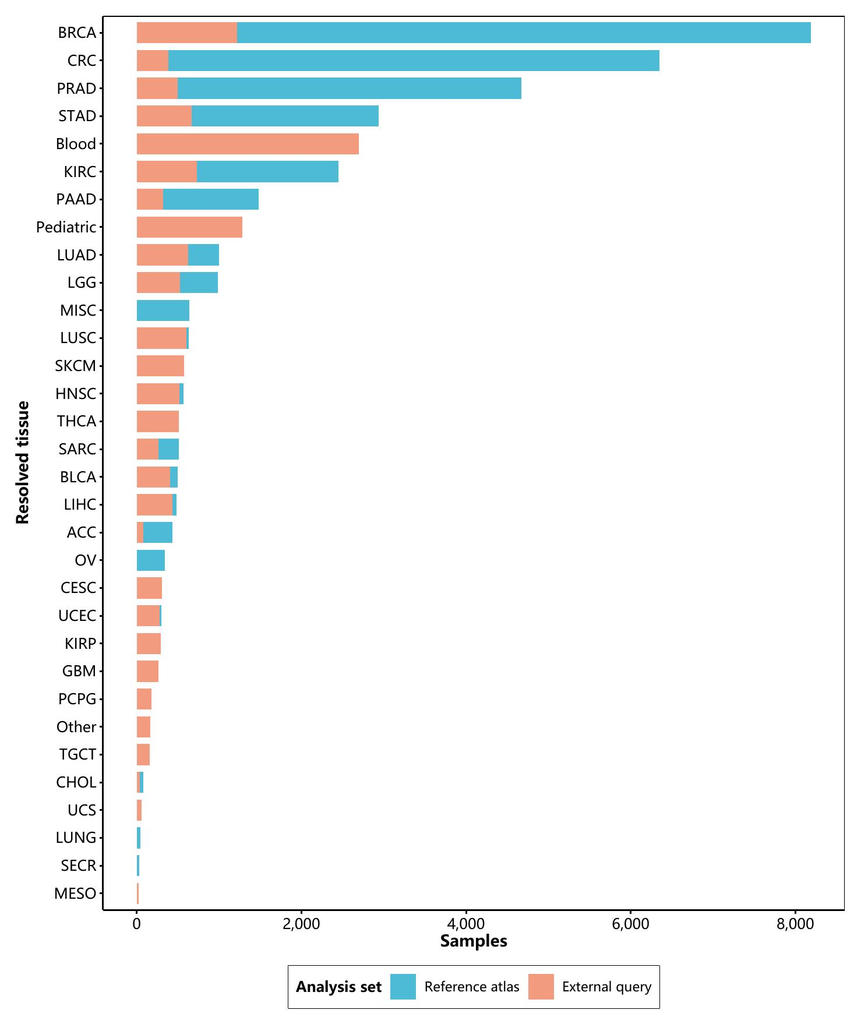

```r
knitr::include_graphics(fig_data1_jpg)
```

#### 结果解读

当前数据结果显示，BRCA 样本量最高（8189 个样本、22 个 cohort），其次为 CRC（6346）和 PRAD（4671）。external query 由冻结模型记录的 filtered cohort 决定，原始层面包含 14083 个样本。**这不是随机训练测试切分；第二阶段仍按独立锚点和重复样本合同重新判定确认性 query。** 这种组织覆盖差异表明样本量只能描述数据规模，不能替代独立 cohort 证据；实验报告会并列给出独立 cohort 数与最终纳入样本数。

## cohort 规模与来源异质性

```r
# ==== Data Figure 2: Cohort scale heterogeneity (user-adjustable parameters) ====
fig_data2 <- list(
  width_in = 7.2,
  height_in = 5.2,
  base_size = 10,
  point_size_min = 2.4,
  point_size_max = 7.5,
  point_alpha = 0.82,
  label_size = 3.0,
  legend_position = "right"
)

p_data2 <- ggplot2::ggplot(
  tissue_totals,
  ggplot2::aes(
    x = .data$cohort_count,
    y = .data$sample_count,
    size = .data$median_cohort_size,
    color = .data$query_fraction
  )
) +
  ggplot2::geom_point(alpha = fig_data2$point_alpha) +
  ggplot2::geom_text(
    data = tissue_label,
    ggplot2::aes(label = .data$tissue),
    size = fig_data2$label_size,
    nudge_y = 0.10,
    check_overlap = TRUE,
    show.legend = FALSE
  ) +
  ggplot2::scale_y_log10(labels = scales::label_number(big.mark = ",")) +
  ggplot2::scale_size_continuous(
    range = c(fig_data2$point_size_min, fig_data2$point_size_max)
  ) +
  ggplot2::scale_color_gradient(
    low = "grey75",
    high = nature_colors[["red"]],
    labels = scales::label_percent(accuracy = 1)
  ) +
  ggplot2::labs(
    x = "Cohorts per tissue",
    y = "Samples per tissue (log scale)",
    size = "Median cohort size",
    color = "External-query share"
  ) +
  theme_nature_readable(
    base_size = fig_data2$base_size,
    x_text_angle = 0,
    legend_position = fig_data2$legend_position
  )

# Readability check: the log scale preserves rare tissues, while labels are
# restricted to the largest tissues to prevent collisions.
fig_data2_jpg <- .atd_save_plot(
  p_data2, "figure-data-02-cohort-scale", figure_dir,
  preview_dir, fig_data2, params$plot_preview_dpi
)
```

```
## Converting page 1 to E:/RCloud/RFactory/ccs/test/ablation-03/tmp/plot-previews/01-ablation-test-data-20260917112244/figure-data-02-cohort-scale.jpg... done!
```

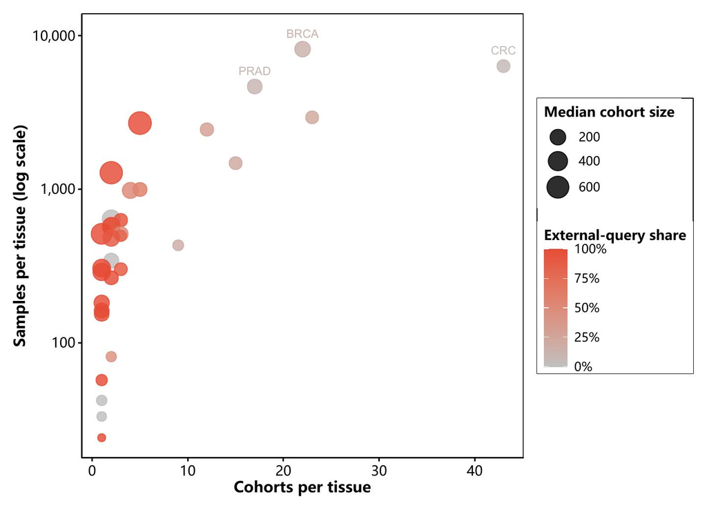

```r
knitr::include_graphics(fig_data2_jpg)
```

#### 结果解读

当前数据结果显示，各 tissue 的 cohort 数与样本数存在跨量级差异；最大单一 cohort 为 BRCA / METABRIC-BRCA-2012，含 1980 个样本。该差异表明样本多不等于独立外部证据更充分，一个大 cohort 可能在样本级汇总中压过多个较小 cohort。稳健性分析采用 cohort-level bootstrap 和 leave-one-cohort-out；若移除最大 cohort 后效应方向翻转，则总体均值不作为跨队列结论。

还需要查看数据来源，因为同一平台或数据库的样本可能共享测量偏差。下面的热图按 tissue 内部归一化，帮助识别是否存在单一 source 主导；这类 tissue 的差异可能同时包含生物差异和来源差异，不能直接视为多次独立重复。

```r
# ==== Data Figure 3: Source-system composition (user-adjustable parameters) ====
fig_data3 <- list(
  width_in = 6.8,
  height_in = 8.8,
  base_size = 9,
  tile_border_width = 0.35,
  legend_position = "right"
)

p_data3 <- ggplot2::ggplot(
  source_profile_plot,
  ggplot2::aes(
    x = .data$source_system,
    y = .data$tissue,
    fill = .data$tissue_fraction
  )
) +
  ggplot2::geom_tile(
    color = "white",
    linewidth = fig_data3$tile_border_width
  ) +
  ggplot2::scale_fill_gradient(
    low = "grey96",
    high = nature_colors[["purple"]],
    labels = scales::label_percent(accuracy = 1),
    limits = c(0, 1)
  ) +
  ggplot2::labs(
    x = "Source system",
    y = "Resolved tissue",
    fill = "Within-tissue share"
  ) +
  theme_nature_readable(
    base_size = fig_data3$base_size,
    x_text_angle = 30,
    legend_position = fig_data3$legend_position
  )

# Readability check: a tall canvas preserves tissue labels, white borders
# separate cells, and the source legend remains outside the heatmap.
fig_data3_jpg <- .atd_save_plot(
  p_data3, "figure-data-03-source-composition", figure_dir,
  preview_dir, fig_data3, params$plot_preview_dpi
)
```

```
## Converting page 1 to E:/RCloud/RFactory/ccs/test/ablation-03/tmp/plot-previews/01-ablation-test-data-20260917112244/figure-data-03-source-composition.jpg... done!
```

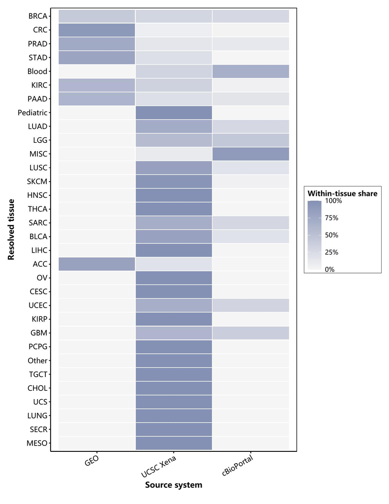

```r
knitr::include_graphics(fig_data3_jpg)
```

#### 结果解读

当前数据结果显示，在 32 个 tissue 中，GEO、cBioPortal 与 UCSC Xena 的支撑比例存在明显差异；图中按 tissue 内部归一化，避免大样本组织遮蔽小组织。**该差异提示，单一 source 占主导的 tissue 不能被当作生物学重复。** 跨来源验证以 BRCA、CRC 和 PRAD 的 source 分层数据为输入，方法为 leave-one-source-out，判据为移除主要来源后效应方向仍一致。

## Biology anchor 数据审计

上面的主数据画像来自 32 特征表达数据；本节单独核对 biology anchor 所依赖的完整表达矩阵入口。完整矩阵由 `01c-ablation03-prepare-biology.R` 一次性读取，再按冻结的四类 gene signature 提取所需基因；因此这里读取的是可追溯的派生缓存，不会在 Rmd 中重复载入大矩阵。

当前缓存状态为 complete，来源文件为 PanCan_CancerSample_DataListForCCS_GEO+cBioPortal+UCXCXenav20240809.rds，包含 316 个唯一 anchor 基因、4 类 anchor、190 个 cohort 和 38547 个目标样本，覆盖 32 个 tissue。这个范围由主实验的完整 reference 与候选 query 合同确定，不再只缓存被选中的邻居；经过输入对齐后，它不等同于上面的全量 39112 个原始样本。

### Anchor 基因覆盖

下表按 anchor 汇总所需基因数、参与的 cohort 数和实际基因覆盖率。覆盖率越低，表示该 anchor 在部分 cohort 中缺少更多 signature 基因；`estimable` 表示至少找到两个基因，可以计算该 cohort 的 anchor 分数。

```r
biology_anchor_summary_display <- biology_profile$anchor_summary
biology_anchor_summary_display$median_coverage <- scales::label_percent(
  accuracy = 0.1
)(biology_anchor_summary_display$median_coverage)
biology_anchor_summary_display$min_coverage <- scales::label_percent(
  accuracy = 0.1
)(biology_anchor_summary_display$min_coverage)
render_dt(biology_anchor_summary_display, pageLength = 10)
```

|  | anchor | genes_required | cohort_count | estimable_cohort_count | median_coverage | min_coverage |
| --- | --- | --- | --- | --- | --- | --- |
| 1 | ifn_il6 | 265 | 190 | 190 | 98.9% | 71.3% |
| 2 | immune_tme | 26 | 190 | 190 | 92.3% | 57.7% |
| 3 | proliferation | 15 | 190 | 190 | 100.0% | 66.7% |
| 4 | stromal_tme | 18 | 190 | 190 | 100.0% | 55.6% |

解读：本次数据中，表格展示 4 类 anchor 的基因覆盖中位数与最低值。最低覆盖偏低提示部分队列的分数依据较少，跨队列效应可能受到测量范围影响。这里的可计算状态只反映基因数门槛，不保证查询样本及两臂全部邻居的分数完整；最终成对覆盖须结合主报告的缺失审计判断，也不能将基因覆盖率直接解释为生物学预测性能。

### Anchor 覆盖率分布图

```r
# Purpose: Audit the full cohort-level signature coverage distribution.
# Input: Derived biology cache coverage; no records are filtered.
# Parameters: Fixed percentage axis and seeded jitter for reproducibility.
# Output: Vector PDF and same-ratio JPG preview embedded in the HTML.
fig_data4 <- list(width_in = 8.2, height_in = 5.8, base_size = 10)
biology_coverage_plot <- biology_profile$coverage
anchor_order <- biology_profile$anchor_summary$anchor
biology_coverage_plot$anchor <- factor(
  biology_coverage_plot$anchor, levels = anchor_order
)
anchor_axis_labels <- with(
  biology_profile$anchor_summary,
  paste0(anchor, "\n", genes_required, " genes\n",
         estimable_cohort_count, "/", cohort_count, " estimable")
)
stopifnot(
  nrow(biology_coverage_plot) == nrow(biology_profile$coverage),
  all(is.finite(biology_coverage_plot$coverage)),
  all(biology_coverage_plot$coverage >= 0 & biology_coverage_plot$coverage <= 1)
)
p_data4 <- ggplot2::ggplot(
  biology_coverage_plot,
  ggplot2::aes(x = .data$anchor, y = .data$coverage)
) +
  ggplot2::geom_hline(yintercept = 1, linetype = "dashed", color = "grey65") +
  ggplot2::geom_boxplot(
    width = 0.45, outlier.shape = NA, fill = "grey95", linewidth = 0.4
  ) +
  ggplot2::geom_point(
    ggplot2::aes(color = .data$status),
    position = ggplot2::position_jitter(width = 0.17, height = 0, seed = 3),
    size = 1.5, alpha = 0.45
  ) +
  ggplot2::scale_color_manual(
    values = c(estimable = nature_colors[["navy"]],
               not_estimable = nature_colors[["red"]]),
    name = "Calculation status"
  ) +
  ggplot2::scale_x_discrete(labels = stats::setNames(anchor_axis_labels, anchor_order)) +
  ggplot2::scale_y_continuous(
    limits = c(0, 1), breaks = seq(0, 1, 0.2),
    labels = scales::label_percent(accuracy = 1),
    expand = ggplot2::expansion(mult = c(0.02, 0.05))
  ) +
  ggplot2::labs(x = NULL, y = "Signature genes found / required") +
  theme_nature_readable(
    base_size = fig_data4$base_size, x_text_angle = 0,
    legend_position = "bottom"
  )
fig_data4_jpg <- .atd_save_plot(
  p_data4, "figure-data-04-biology-anchor-coverage", figure_dir,
  preview_dir, fig_data4, params$plot_preview_dpi
)
```

```
## Converting page 1 to E:/RCloud/RFactory/ccs/test/ablation-03/tmp/plot-previews/01-ablation-test-data-20260917112244/figure-data-04-biology-anchor-coverage.jpg... done!
```

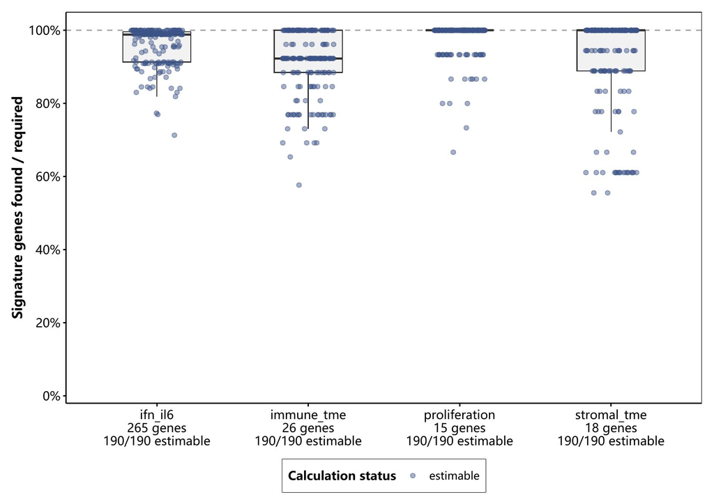

```r
knitr::include_graphics(fig_data4_jpg)
```

#### 图形解读

本图保留全部 760 条记录；覆盖率低于 100% 的记录有 382 条。四类 anchor 的最低覆盖率依次为 ifn_il6 = 71.3%；immune_tme = 57.7%；proliferation = 66.7%；stromal_tme = 55.6%。靠近顶部的点表示 signature 基因较完整，较低的点提示应在下方明细表核查具体 cohort 与基因标识类型。可计算只要求至少找到两个基因，不等同于 signature 完整，也不证明跨组织或跨来源的生物学有效性。

#### 结果解读

观察：四类 anchor 在当前缓存中共有 760 条 cohort-anchor 审计记录，其中 760 条达到可计算条件。The table displays coverage differences across anchors and indicates which cohorts are estimable. 结论：这里的基因覆盖率审计回答的是“完整表达矩阵中是否找得到 signature 基因”，不是模型效果评价；即使覆盖率较高，也不能单独证明 anchor 在不同来源或不同组织中的生物学解释完全一致。

### Cohort 级覆盖明细

```r
biology_coverage_display <- biology_profile$coverage[, c(
  "tissue", "cohort", "anchor", "genes_required", "genes_found",
  "coverage", "sample_count", "id_type", "status"
)]
biology_coverage_display$coverage <- scales::label_percent(accuracy = 0.1)(
  biology_coverage_display$coverage
)
render_dt(biology_coverage_display, pageLength = 15)
```

|  | tissue | cohort | anchor | genes_required | genes_found | coverage | sample_count | id_type | status |
| --- | --- | --- | --- | --- | --- | --- | --- | --- | --- |
| 1 | ACC | GSE143383 | proliferation | 15 | 15 | 100.0% | 63 | ENSEMBL | estimable |
| 2 | ACC | GSE143383 | immune_tme | 26 | 24 | 92.3% | 63 | ENSEMBL | estimable |
| 3 | ACC | GSE143383 | stromal_tme | 18 | 16 | 88.9% | 63 | ENSEMBL | estimable |
| 4 | ACC | GSE143383 | ifn_il6 | 265 | 265 | 100.0% | 63 | ENSEMBL | estimable |
| 5 | ACC | GSE19750 | proliferation | 15 | 15 | 100.0% | 48 | ENSEMBL | estimable |
| 6 | ACC | GSE19750 | immune_tme | 26 | 24 | 92.3% | 48 | ENSEMBL | estimable |
| 7 | ACC | GSE19750 | stromal_tme | 18 | 18 | 100.0% | 48 | ENSEMBL | estimable |
| 8 | ACC | GSE19750 | ifn_il6 | 265 | 262 | 98.9% | 48 | ENSEMBL | estimable |
| 9 | ACC | GSE33371 | proliferation | 15 | 15 | 100.0% | 55 | ENSEMBL | estimable |
| 10 | ACC | GSE33371 | immune_tme | 26 | 24 | 92.3% | 55 | ENSEMBL | estimable |

[output cut: 90 more lines]

观察：该明细表保留每个 tissue/cohort/anchor 的原始覆盖证据，便于定位某个 anchor 是否因缺少基因而不可估计。The table displays the source evidence and indicates where coverage is lower. 结论：它与上方 32 特征数据表是互补关系，前者检查 biology 输入是否足够，后者检查主消融数据的组织、来源和 reference-query 构成。

## 讨论与分析

第一阶段确认了 tissue 恢复没有改变样本总数或 cohort 总数，45 个历史 `Undefined` cohort 均可追溯到已核验组织，剩余未解析样本为 0。同时，reference-query 构成与 source system 明显不均衡，因此第二阶段不能把样本级重复当作独立 cohort 证据，也不能把 filtered cohort 直接等同于最终确认性 query。

该审计不评价 d1 的优劣。消融实验的输入边界是保留历史 bank key 以复现冻结模型、使用恢复后的 tissue key 做分层，并对来源占主导和 cohort 规模失衡进行显式敏感性分析。biology anchor 另以完整表达矩阵派生的 316 个基因作为输入，当前缓存覆盖 38547 个目标样本；02-ablation03-representation.Rmd 将在相同数据画像上报告真正进入外部比较的样本、cohort 和表示合同。

## 数字准确性验证

| 数字描述 | 来源变量/计算 | 结果位置 |
| --- | --- | --- |
| 样本、cohort 与 tissue 总数 | `data_profile$overview` | E:/RCloud/RFactory/ccs/test/ablation-03/tmp/01-data/data-profile.rds |
| tissue 恢复规模 | `data_profile$resolution_audit` | 同上 |
| reference-query 原始构成 | `data_profile$tissue_profile` | 同上 |
| cohort 与来源异质性 | `data_profile$tissue_totals` / `$source_profile` | 同上 |
| biology anchor 基因与覆盖 | `biology_profile$anchor_summary` / `$coverage` | E:/RCloud/RFactory/ccs/test/ablation-03/tmp/01-biology/expression-anchor-cache.rds |

主数据画像的核心数字均从 `data-profile.rds` 动态嵌入；biology 数字均从 `expression-anchor-cache.rds` 动态嵌入。三张主数据图和一张 biology anchor 覆盖率图均由对应审计对象生成矢量 PDF，再转换为保持相同比例的 JPG 供 HTML 展示；Rmd 只读取 biology 派生缓存，不重复加载完整表达矩阵，也未对数据应用业务阈值。